# 20190128 | RLEL Workshop: R for Descriptive Stats

Miranda Haus

January 28, 2019

## A Quick Intro to R Markdown

### Including code chunks

- Check your R/RStudio versions
- For the time-being install the individual packages using `install.packages("PACKAGENAME")`
- Check out the whole `tidyverse` suite of packages [here](https://www.tidyverse.org/packages/)

# Package installation

Install the relevant packages we will use, including our data for today, using the `install.packages()` function.

We’re going to set `eval = FALSE` so that it doesn’t run everytime this document is knit in Rmarkdown.

```r
# data import packages
  install.packages("gapminder") # Dataset we will use today
  install.packages("here")      # Finding files
  install.packages("readr")     # Importing data files
  install.packages("readxl")    # Importing excel files

# data manipulation packages
  install.packages("tidyverse") # Tidyverse
  install.packages("tidyr")     # Tidy Data (part of tidyverse)
  install.packages("dplyr")     # Data manipulation (part of tidyverse)

# data visualization and statistical packages
  install.packages("ggplot2")     # Data Visualization (w/ Grammar of Graphics)
  install.packages("psych")     # Data visualization and stats
  install.packages("vioplot")   # Data visualization and stats
  install.packages("GGally")    # Data visualization and stats
```

A note about `vioplot`:

If you get this message:

```
Error in library(vioplot) : there is no package called 'vioplot'
```

Try installing it separately through the console. Then, if you get a message that says:

```
Do you want to install from sources the package which needs compilation?
y/n:
```

Type **y**.

### Loading packages

```r
# in Rmarkdown, eval needs to be true (eval=T) to load libraries below
# echo=T to show the code
# message=F to hide messages from loading the packages

library(tidyverse) # package to work with tidy data & visualization

# OR: load the individual packages:
#library(readr)    # part of tidyverse
#library(tidyr)    # part of tidyverse
#library(dplyr)    # part of tidyverse
#library(ggplot2)  # part of tidyverse
#library(purrr)    # part of tidyverse

library(readxl)   # To read Excel files
library(psych)     # has a few useful statistical functions
library(vioplot)   # to make violin plots
library(here)      # To find your files; set the working directory
library(gapminder) # Gapminder data: life expectancy, GDP per capita, population by country
```

# Data exploration

First things first, look at raw data structure. Knowing how your data looks overall will help you analyze and organize it.

```r
# View(gapminder)

# Using the base r function "str" shows dataype and unique values.
  str(gapminder)
```

```
## Classes 'tbl_df', 'tbl' and 'data.frame':    1704 obs. of  6 variables:
##  $ country  : Factor w/ 142 levels "Afghanistan",..: 1 1 1 1 1 1 1 1 1 1 ...
##  $ continent: Factor w/ 5 levels "Africa","Americas",..: 3 3 3 3 3 3 3 3 3 3 ...
##  $ year     : int  1952 1957 1962 1967 1972 1977 1982 1987 1992 1997 ...
##  $ lifeExp  : num  28.8 30.3 32 34 36.1 ...
##  $ pop      : int  8425333 9240934 10267083 11537966 13079460 14880372 12881816 13867957 16317921 22227415 ...
##  $ gdpPercap: num  779 821 853 836 740 ...
```

Compare base R to the tidyverse function `glimpse()`, which shows datatype and lists the first few rows.

```r
# glimpse from `tidyverse`
  glimpse(gapminder)
```

```
## Observations: 1,704
## Variables: 6
## $ country   <fct> Afghanistan, Afghanistan, Afghanistan, Afghanistan, ...
## $ continent <fct> Asia, Asia, Asia, Asia, Asia, Asia, Asia, Asia, Asia...
## $ year      <int> 1952, 1957, 1962, 1967, 1972, 1977, 1982, 1987, 1992...
## $ lifeExp   <dbl> 28.801, 30.332, 31.997, 34.020, 36.088, 38.438, 39.8...
## $ pop       <int> 8425333, 9240934, 10267083, 11537966, 13079460, 1488...
## $ gdpPercap <dbl> 779.4453, 820.8530, 853.1007, 836.1971, 739.9811, 78...
```

```r
# We can also look at the first 10 rows.
  head(gapminder)
```

```
## # A tibble: 6 x 6
##   country     continent  year lifeExp      pop gdpPercap
##   <fct>       <fct>     <int>   <dbl>    <int>     <dbl>
## 1 Afghanistan Asia       1952    28.8  8425333      779.
## 2 Afghanistan Asia       1957    30.3  9240934      821.
## 3 Afghanistan Asia       1962    32.0 10267083      853.
## 4 Afghanistan Asia       1967    34.0 11537966      836.
## 5 Afghanistan Asia       1972    36.1 13079460      740.
## 6 Afghanistan Asia       1977    38.4 14880372      786.
```

```r
# and look at the last 10 rows.
  tail(gapminder)
```

```
## # A tibble: 6 x 6
##   country  continent  year lifeExp      pop gdpPercap
##   <fct>    <fct>     <int>   <dbl>    <int>     <dbl>
## 1 Zimbabwe Africa     1982    60.4  7636524      789.
## 2 Zimbabwe Africa     1987    62.4  9216418      706.
## 3 Zimbabwe Africa     1992    60.4 10704340      693.
## 4 Zimbabwe Africa     1997    46.8 11404948      792.
## 5 Zimbabwe Africa     2002    40.0 11926563      672.
## 6 Zimbabwe Africa     2007    43.5 12311143      470.
```

`View()` will open the dataset in a new tab.

```r
# Open the dataset in a new tab.
  #View(gapminder)
```

```r
#If you're working with large data sets, it could be useful to take a random sample of your data to get a feel for it.

mysample <- gapminder[sample(1:nrow(gapminder), 20, replace = FALSE),]

mysample
```

```
## # A tibble: 20 x 6
##    country       continent  year lifeExp       pop gdpPercap
##    <fct>         <fct>     <int>   <dbl>     <int>     <dbl>
##  1 Mali          Africa     1992    48.4   8416215      739.
##  2 Mauritania    Africa     1967    46.3   1230542     1421.
##  3 France        Europe     1972    72.4  51732000    16107.
##  4 Peru          Americas   1957    46.3   9146100     4245.
##  5 Malawi        Africa     1962    38.4   3628608      428.
##  6 Madagascar    Africa     1997    55.0  14165114      986.
##  7 United States Americas   1972    71.3 209896000    21806.
##  8 Gabon         Africa     1952    37.0    420702     4293.
##  9 Mauritius     Africa     1957    58.1    609816     2034.
## 10 United States Americas   1977    73.4 220239000    24073.
## 11 Venezuela     Americas   1997    72.1  22374398    10165.
## 12 Iceland       Europe     1982    77.0    233997    23270.
## 13 Algeria       Africa     1957    45.7  10270856     3014.
## 14 Iran          Asia       2007    71.0  69453570    11606.
## 15 Canada        Americas   1957    70.0  17010154    12490.
## 16 Botswana      Africa     2002    46.6   1630347    11004.
## 17 Panama        Americas   1977    68.7   1839782     5352.
## 18 Tunisia       Africa     2007    73.9  10276158     7093.
## 19 Morocco       Africa     1972    52.9  16660670     1930.
## 20 Canada        Americas   2002    79.8  31902268    33329.
```

If you ever need a reminder of your column names and order, use the function `colnames()`.

```r
# get column names
  colnames(gapminder)
```

```
## [1] "country"   "continent" "year"      "lifeExp"   "pop"       "gdpPercap"
```

## Checking for missing data

Start by checking for missing data using the `summary()` function. If there are missing data points (NA), you will see them in the bottom row, but only for the variable that is missing data.

```r
# get summary
  summary(gapminder)
```

```
##         country        continent        year         lifeExp
##  Afghanistan:  12   Africa  :624   Min.   :1952   Min.   :23.60
##  Albania    :  12   Americas:300   1st Qu.:1966   1st Qu.:48.20
##  Algeria    :  12   Asia    :396   Median :1980   Median :60.71
##  Angola     :  12   Europe  :360   Mean   :1980   Mean   :59.47
##  Argentina  :  12   Oceania : 24   3rd Qu.:1993   3rd Qu.:70.85
##  Australia  :  12                  Max.   :2007   Max.   :82.60
##  (Other)    :1632
##       pop              gdpPercap
##  Min.   :6.001e+04   Min.   :   241.2
##  1st Qu.:2.794e+06   1st Qu.:  1202.1
##  Median :7.024e+06   Median :  3531.8
##  Mean   :2.960e+07   Mean   :  7215.3
##  3rd Qu.:1.959e+07   3rd Qu.:  9325.5
##  Max.   :1.319e+09   Max.   :113523.1
##
```

The `describe()` function from the `psych` package gives a more detailed summary. Notice what happens with categorical variables.

```r
# And we can compare this to 'psych' package.
  describe(gapminder)
```

```
##            vars    n        mean           sd     median     trimmed
## country*      1 1704       71.50        41.00      71.50       71.50
## continent*    2 1704        2.33         1.21       2.00        2.27
## year          3 1704     1979.50        17.27    1979.50     1979.50
## lifeExp       4 1704       59.47        12.92      60.71       59.92
## pop           5 1704 29601212.32 106157896.74 7023595.50 11399459.45
## gdpPercap     6 1704     7215.33      9857.45    3531.85     5221.44
##                   mad      min          max      range  skew kurtosis
## country*        52.63     1.00        142.0        141  0.00    -1.20
## continent*       1.48     1.00          5.0          4  0.25    -1.34
## year            22.24  1952.00       2007.0         55  0.00    -1.22
## lifeExp         16.10    23.60         82.6         59 -0.25    -1.13
## pop        7841473.62 60011.00 1318683096.0 1318623085  8.33    77.62
## gdpPercap     4007.61   241.17     113523.1     113282  3.84    27.40
##                    se
## country*         0.99
## continent*       0.03
## year             0.42
## lifeExp          0.31
## pop        2571683.45
## gdpPercap      238.80
```

A note about `attach()`: it’s best not to attach; what if many datasets have the same column names?!

```r
# "attach" - best not to attach; what if many datasets have the same column names?!
  # attach(gapminder)
```

# Histogram: to view distributions

Plot a histogram to look at the distribution of your data.

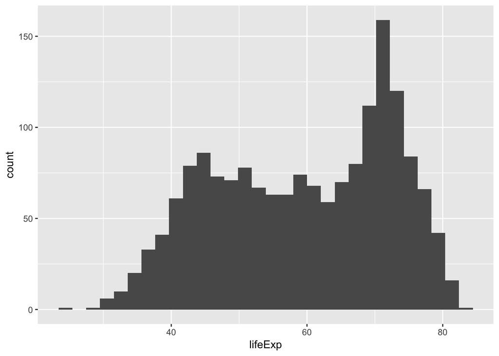

```r
# histogram of life expectancy
  gapminder %>%
    ggplot(aes(x = lifeExp)) +
    geom_histogram()
```

Option to try using base R.

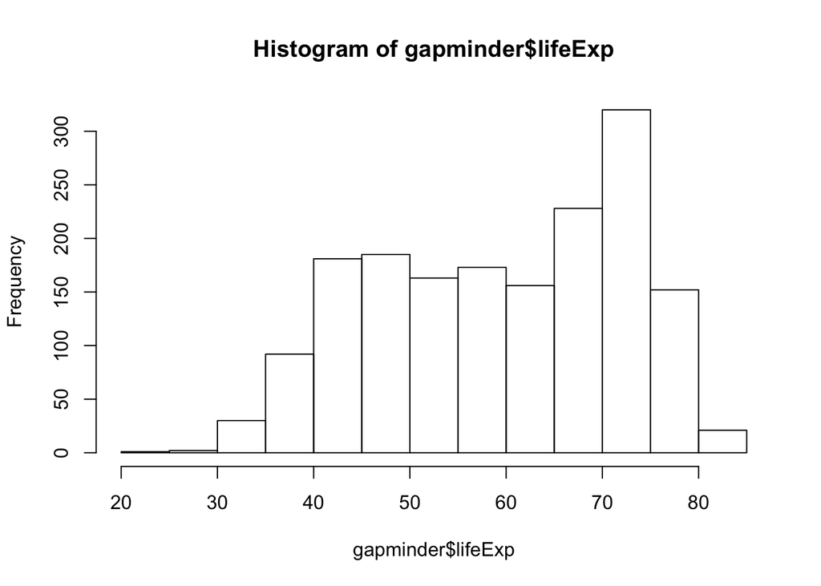

```r
# histogram using base R
   hist(gapminder$lifeExp)
```

# Descriptive statistics 101

Here, we use the `summary` function again, but this time for a variable, not a dataset. This gives us a table of basic stats including minimum, median, quartiles, and min/max.

```r
# summary for life expectancy only
  gapminder %>%
    pull(lifeExp) %>%
    summary()
```

```
##    Min. 1st Qu.  Median    Mean 3rd Qu.    Max.
##   23.60   48.20   60.71   59.47   70.85   82.60
```

Extract these numbers separately.

```r
# Use any of these to recall a single descriptor.
  max(gapminder$lifeExp)
```

```
## [1] 82.603
```

```r
  min(gapminder$lifeExp)
```

```
## [1] 23.599
```

```r
  range(gapminder$lifeExp)
```

```
## [1] 23.599 82.603
```

```r
  median(gapminder$lifeExp)
```

```
## [1] 60.7125
```

```r
  mode(gapminder$lifeExp)
```

```
## [1] "numeric"
```

```r
  mean(gapminder$lifeExp)
```

```
## [1] 59.47444
```

```r
  quantile(gapminder$lifeExp)
```

```
##      0%     25%     50%     75%    100%
## 23.5990 48.1980 60.7125 70.8455 82.6030
```

You can also make calculations from portions of the data set.

```r
# calculate the mean of selected samples
  mean(gapminder$lifeExp[1:10])
```

```
## [1] 36.3789
```

```r
# we can select the rows the are from Bulgaria
  median(gapminder$lifeExp[1:10])
```

```
## [1] 37.263
```

```r
# mode does not work for the small data set because no number appears twice
  mode(gapminder$lifeExp[1:10])
```

```
## [1] "numeric"
```

# Summary statistics

There are many ways to get summary statistics by grouping.

For example, if we wanted to get summary statistics of “lifeExp”" by continent:

## Using base R: `tapply()`

```r
tapply(gapminder$lifeExp,
       gapminder$continent,
       summary)
```

```
## $Africa
##    Min. 1st Qu.  Median    Mean 3rd Qu.    Max.
##   23.60   42.37   47.79   48.87   54.41   76.44
##
## $Americas
##    Min. 1st Qu.  Median    Mean 3rd Qu.    Max.
##   37.58   58.41   67.05   64.66   71.70   80.65
##
## $Asia
##    Min. 1st Qu.  Median    Mean 3rd Qu.    Max.
##   28.80   51.43   61.79   60.06   69.51   82.60
##
## $Europe
##    Min. 1st Qu.  Median    Mean 3rd Qu.    Max.
##   43.59   69.57   72.24   71.90   75.45   81.76
##
## $Oceania
##    Min. 1st Qu.  Median    Mean 3rd Qu.    Max.
##   69.12   71.20   73.67   74.33   77.55   81.23
```

## Using dplyr: `summarize()`

```r
# Note how we used 'na.rm=TRUE' to remove missing data (if needed).
gapminder %>%
  group_by(continent) %>%
  summarize(mean=mean(lifeExp, na.rm=T),
            median=median(lifeExp, na.rm=T))
```

```
## # A tibble: 5 x 3
##   continent  mean median
##   <fct>     <dbl>  <dbl>
## 1 Africa     48.9   47.8
## 2 Americas   64.7   67.0
## 3 Asia       60.1   61.8
## 4 Europe     71.9   72.2
## 5 Oceania    74.3   73.7
```

## Using purrr: `split()` & `map()`

```r
gapminder %>%
  split(.$continent) %>%
  map(summary)
```

```
## $Africa
##          country       continent        year         lifeExp
##  Algeria     : 12   Africa  :624   Min.   :1952   Min.   :23.60
##  Angola      : 12   Americas:  0   1st Qu.:1966   1st Qu.:42.37
##  Benin       : 12   Asia    :  0   Median :1980   Median :47.79
##  Botswana    : 12   Europe  :  0   Mean   :1980   Mean   :48.87
##  Burkina Faso: 12   Oceania :  0   3rd Qu.:1993   3rd Qu.:54.41
##  Burundi     : 12                  Max.   :2007   Max.   :76.44
##  (Other)     :552
##       pop              gdpPercap
##  Min.   :    60011   Min.   :  241.2
##  1st Qu.:  1342075   1st Qu.:  761.2
##  Median :  4579311   Median : 1192.1
##  Mean   :  9916003   Mean   : 2193.8
##  3rd Qu.: 10801490   3rd Qu.: 2377.4
##  Max.   :135031164   Max.   :21951.2
##
##
## $Americas
##       country       continent        year         lifeExp
##  Argentina: 12   Africa  :  0   Min.   :1952   Min.   :37.58
##  Bolivia  : 12   Americas:300   1st Qu.:1966   1st Qu.:58.41
##  Brazil   : 12   Asia    :  0   Median :1980   Median :67.05
##  Canada   : 12   Europe  :  0   Mean   :1980   Mean   :64.66
##  Chile    : 12   Oceania :  0   3rd Qu.:1993   3rd Qu.:71.70
##  Colombia : 12                  Max.   :2007   Max.   :80.65
##  (Other)  :228
##       pop              gdpPercap
##  Min.   :   662850   Min.   : 1202
##  1st Qu.:  2962359   1st Qu.: 3428
##  Median :  6227510   Median : 5466
##  Mean   : 24504795   Mean   : 7136
##  3rd Qu.: 18340309   3rd Qu.: 7830
##  Max.   :301139947   Max.   :42952
##
##
## $Asia
##              country       continent        year         lifeExp
##  Afghanistan     : 12   Africa  :  0   Min.   :1952   Min.   :28.80
##  Bahrain         : 12   Americas:  0   1st Qu.:1966   1st Qu.:51.43
```

[output cut: 34 more lines]

```
##  Australia  :12   Africa  : 0   Min.   :1952   Min.   :69.12
##  New Zealand:12   Americas: 0   1st Qu.:1966   1st Qu.:71.20
##  Afghanistan: 0   Asia    : 0   Median :1980   Median :73.67
##  Albania    : 0   Europe  : 0   Mean   :1980   Mean   :74.33
##  Algeria    : 0   Oceania :24   3rd Qu.:1993   3rd Qu.:77.55
##  Angola     : 0                 Max.   :2007   Max.   :81.23
##  (Other)    : 0
##       pop             gdpPercap
##  Min.   : 1994794   Min.   :10040
##  1st Qu.: 3199212   1st Qu.:14142
##  Median : 6403492   Median :17983
##  Mean   : 8874672   Mean   :18622
##  3rd Qu.:14351625   3rd Qu.:22214
##  Max.   :20434176   Max.   :34435
##
```

## Using psych: `describeBy()`

```r
describeBy(gapminder$lifeExp,
           gapminder$continent,
           mat = TRUE)
```

```
##     item   group1 vars   n     mean        sd  median  trimmed       mad
## X11    1   Africa    1 624 48.86533  9.150210 47.7920 48.29597  8.580547
## X12    2 Americas    1 300 64.65874  9.345088 67.0480 65.50320  8.467129
## X13    3     Asia    1 396 60.06490 11.864532 61.7915 60.62415 13.002402
## X14    4   Europe    1 360 71.90369  5.433178 72.2410 72.38535  4.432974
## X15    5  Oceania    1  24 74.32621  3.795611 73.6650 74.18570  4.003020
##        min    max  range       skew   kurtosis        se
## X11 23.599 76.442 52.843  0.5631664  0.1335922 0.3663016
## X12 37.579 80.653 43.074 -0.7349497 -0.2072983 0.5395389
## X13 28.801 82.603 53.802 -0.4010686 -0.6664275 0.5962151
## X14 43.585 81.757 38.172 -1.2461037  3.2857630 0.2863536
## X15 69.120 81.235 12.115  0.3679214 -1.3277465 0.7747759
```

In short, there are many ways to get the same information, so play around!

# Saving tables

What if we want to save the table as a file?

```r
# set locations for saving
  getwd()        # get working directory
```

```
## [1] "/Users/janani/Google_Drive/GitHub/meetup-presentations-eastlansing/presentations/20190204-workshop-rstats"
```

```r
  here::here()   # set working directory
```

```
## [1] "/Users/janani/Google_Drive/GitHub/meetup-presentations-eastlansing"
```

```r
  # setwd("C:/Users/Miranda Haus/Documents/RLadies_Workshops") # alternative way to set working directory

# save the table as a CSV (comma-separated values) file
  describeBy(gapminder$lifeExp,
             gapminder$continent,
             mat = TRUE) %>%
        write.csv(file="test.csv")
```

Alternatively, you can make a new variable and write it instead.

```r
# create new variable
  test2 <- describeBy(gapminder$lifeExp, gapminder$continent, mat = TRUE)

# save as CSV
 write.csv(test2, "test2.csv")
```

# Residuals

You may or may not want to see residuals based on your experience/field/etc. Here, we can plot them in QQ (quantile-quantile) plot.

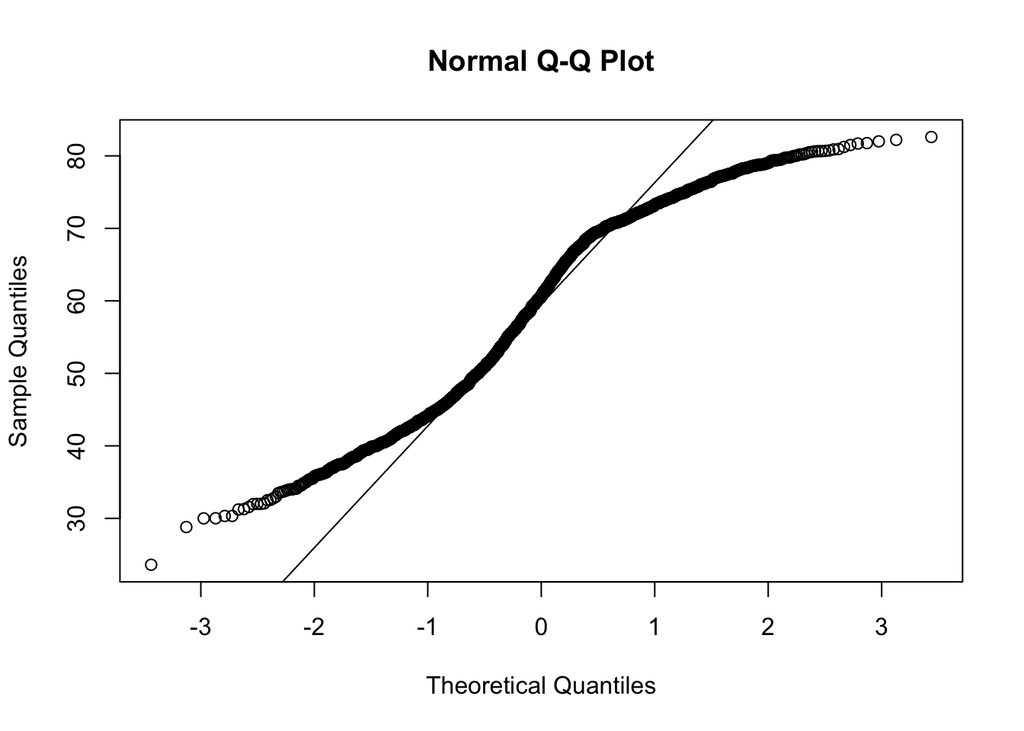

```r
# plot residuals
  qqnorm(gapminder$lifeExp)
  qqline(gapminder$lifeExp)
```

# Plotting your statistics

Let’s graph these descriptive statistics so they are interpretable by our readers (e.g. boss, reviewer, etc.).

## Making boxlots: to view distributions/summary stats/outliers

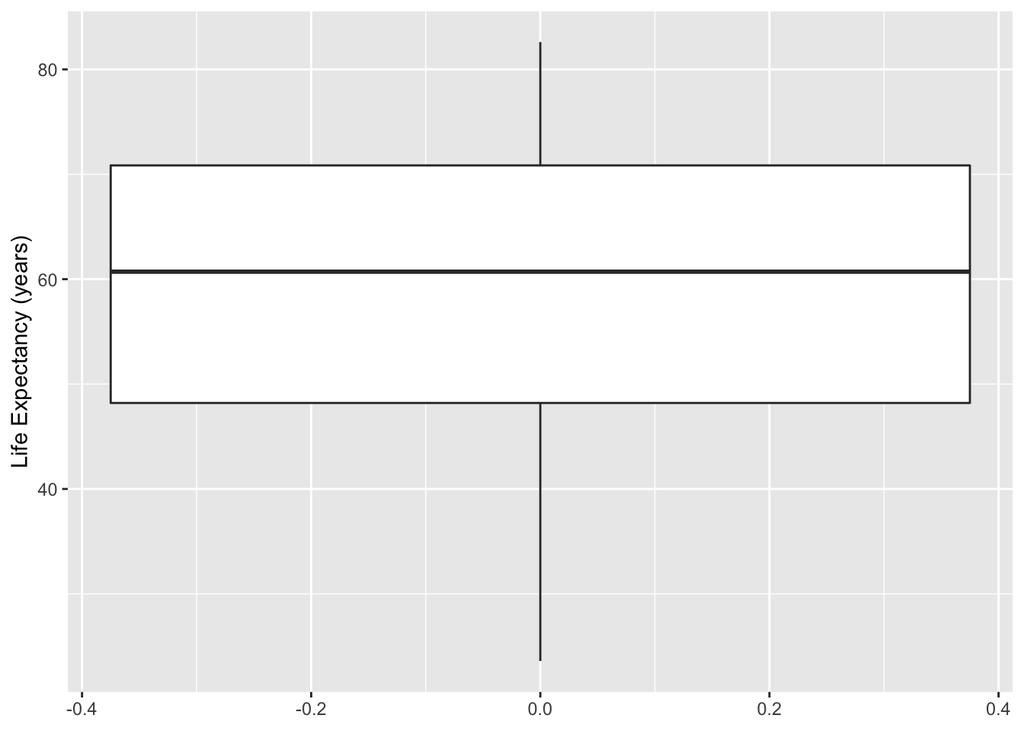

```r
gapminder %>%
  ggplot(aes( y = lifeExp)) +
  geom_boxplot() +
  ylab("Life Expectancy (years)")
```

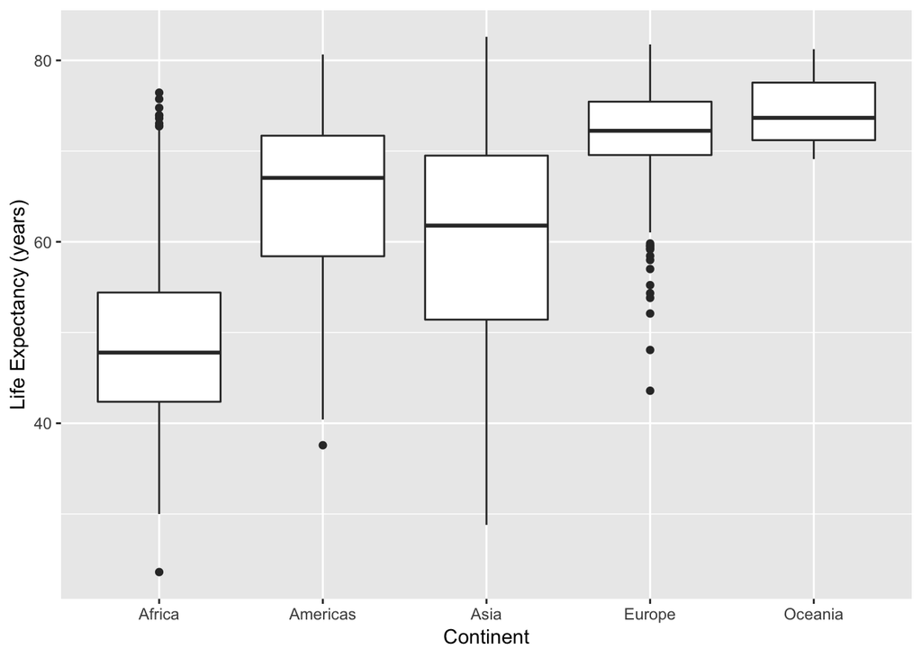

```r
gapminder %>%
  ggplot(aes(x = continent, y = lifeExp)) +
  geom_boxplot() +
  xlab("Continent") +
  ylab("Life Expectancy (years)")
```

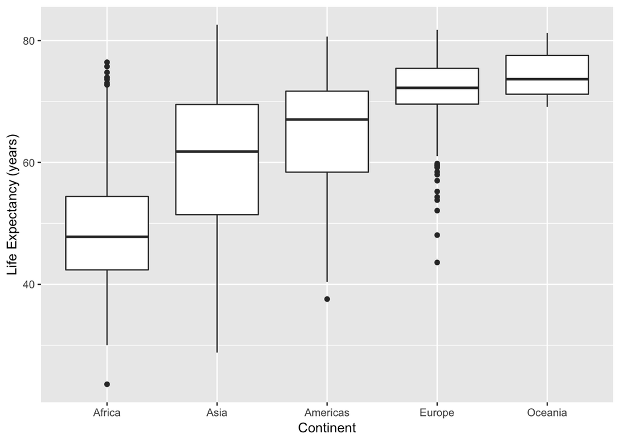

```r
gapminder %>%
  ggplot(aes(x = reorder(continent, lifeExp, FUN = median),
             y = lifeExp)) +
  geom_boxplot() +
  xlab("Continent") +
  ylab("Life Expectancy (years)")
```

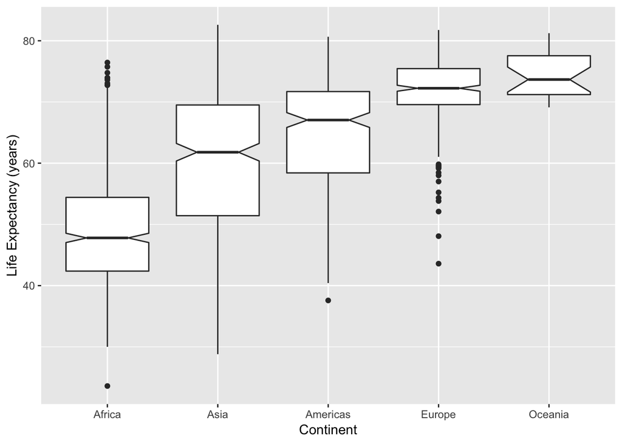

```r
gapminder %>%
  ggplot(aes(x = reorder(continent, lifeExp, FUN = median),
             y = lifeExp)) +
  geom_boxplot(notch = T) +
  xlab("Continent") +
  ylab("Life Expectancy (years)")
```

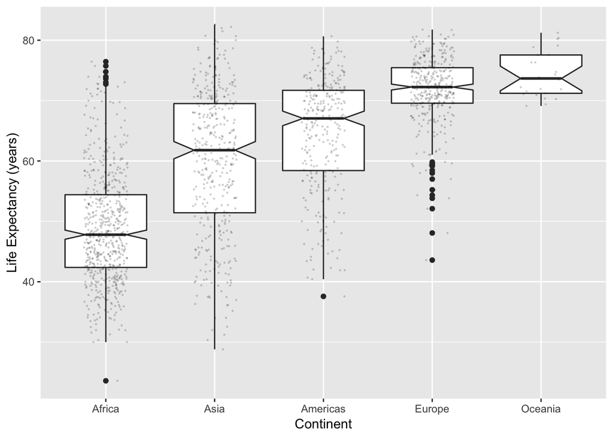

```r
gapminder %>%
  ggplot(aes(x = reorder(continent, lifeExp, FUN = median),
             y = lifeExp)) +
  geom_boxplot(notch = T) +
  geom_jitter(shape=16, position=position_jitter(0.2), size=0.5, alpha = 0.2) +
  xlab("Continent") +
  ylab("Life Expectancy (years)")
```

Here are options to try it using base R instead.

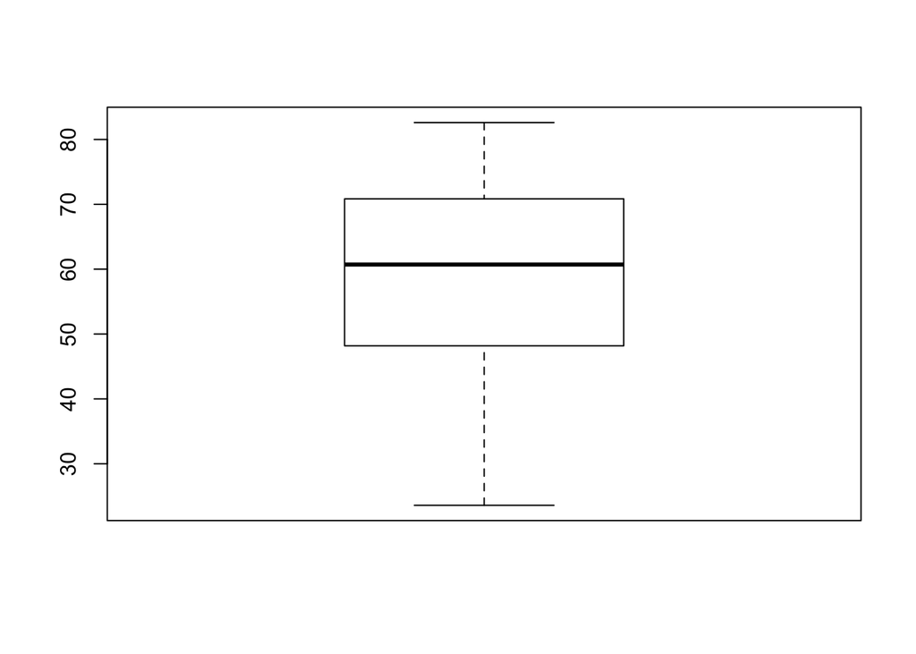

```r
## Using base R
boxplot(gapminder$lifeExp)
```

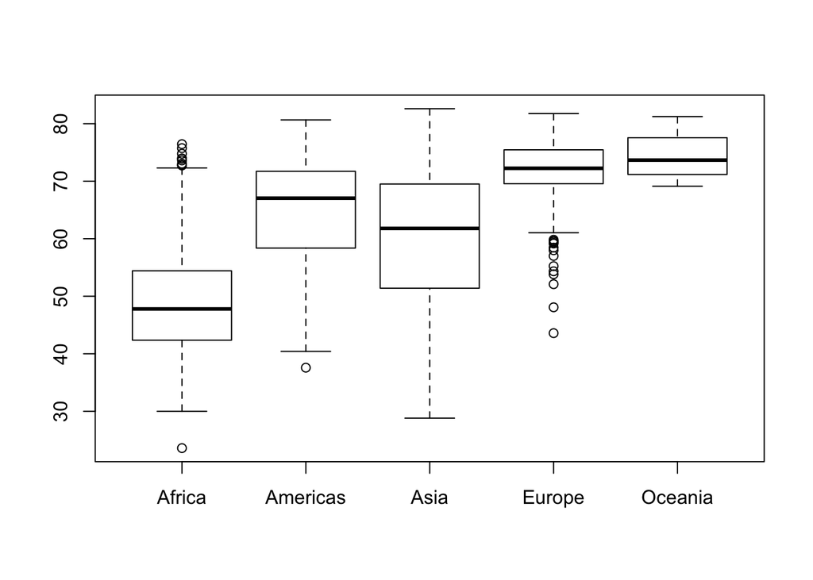

```r
# Or look at boxplots across group
boxplot(gapminder$lifeExp~gapminder$continent)
```

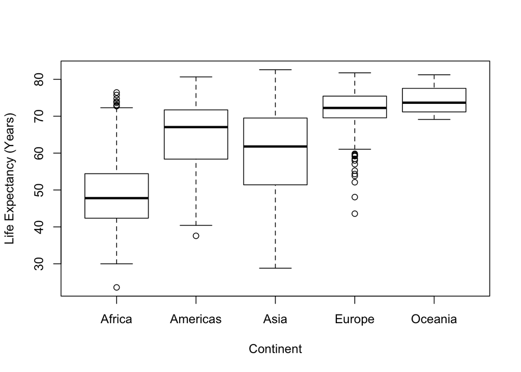

```r
boxplot(gapminder$lifeExp~gapminder$continent,
        xlab="Continent", ylab="Life Expectancy (Years)")
```

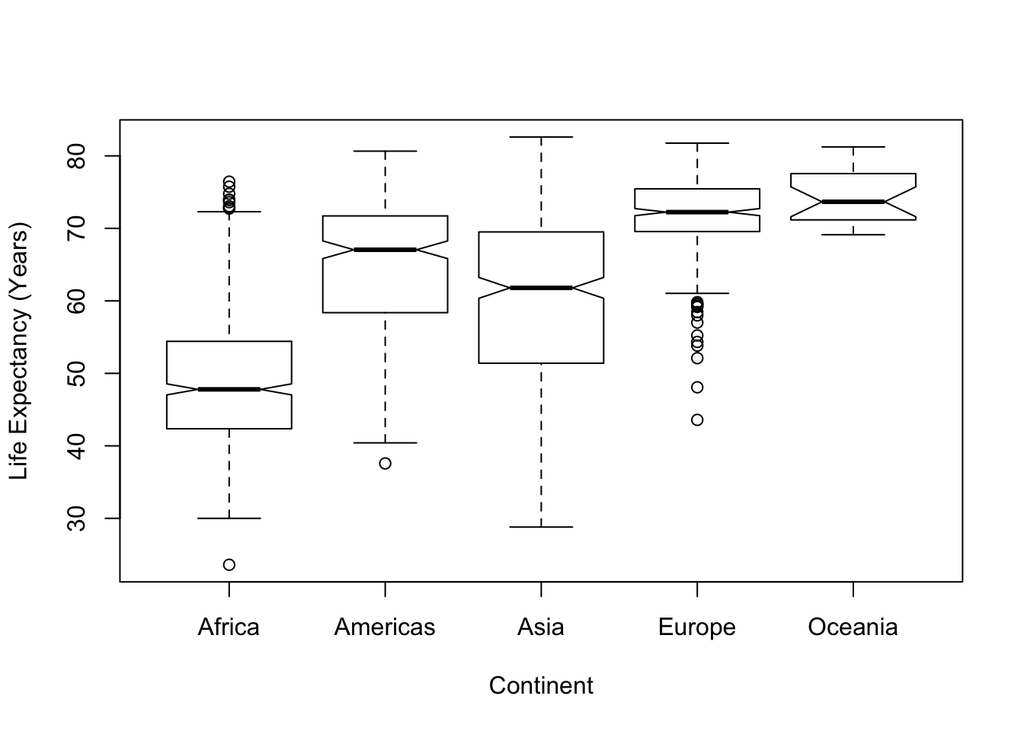

```r
# You can add notches to
boxplot(gapminder$lifeExp~gapminder$continent,
        notch=T, xlab="Continent", ylab="Life Expectancy (Years)")
```

# Finding outliers

Now that we know what’s common in our data set, let’s look at what is uncommon or weird.

```r
# boxplot for life expectancy
  outliers_lifeExp <- boxplot.stats(gapminder$lifeExp)$out # outlier values.
  outliers_lifeExp
```

```
## numeric(0)
```

Well… lifeExp doesn’t have any outliers. So let’s look at a variable that does:

```r
# boxplot for population
  outliers_pop <- boxplot.stats(gapminder$pop)$out
  outliers_pop
```

```
##   [1]   46886859   51365468   56839289   62821884   70759295   80428306
##   [7]   93074406  103764241  113704579  123315288  135656790  150448339
##  [13]   56602560   65551171   76039390   88049823  100840058  114313951
##  [19]  128962939  142938076  155975974  168546719  179914212  190010647
##  [25]  556263527  637408000  665770000  754550000  862030000  943455000
##  [31] 1000281000 1084035000 1164970000 1230075000 1280400000 1318683096
##  [37]   47798986   55379852   64606759   45681811   52799062   59402198
##  [43]   66134291   73312559   80264543   52088559   59861301   67946797
##  [49]   76511887   47124000   49569000   51732000   53165019   54433565
##  [55]   55630100   57374179   58623428   59925035   61083916   69145952
##  [61]   71019069   73739117   76368453   78717088   78160773   78335266
##  [67]   77718298   80597764   82011073   82350671   82400996  372000000
##  [73]  409000000  454000000  506000000  567000000  634000000  708000000
##  [79]  788000000  872000000  959000000 1034172547 1110396331   82052000
##  [85]   90124000   99028000  109343000  121282000  136725000  153343000
```

[output cut: 20 more lines]

we found them! Great! But how can I go back to my dataset to find these outliers specifically?

Let’s create a subset of the data that includes only observations above our minimum outlier.

```r
# subset of minimum outliers only
  min(outliers_pop)
```

```
## [1] 45598081
```

```r
  out.set <-filter(gapminder, pop >= '45598081')

# inspect
  View(out.set)
```

Now I can find the outliers and go back to my original dataset. When would you want to do this?

# Violin plots: for seeing shape of distribution

Violin plots are more descriptive wasy to visualize box plots.They overlap distrbution and key statistics (e.g. mean, quartiles, etc.)

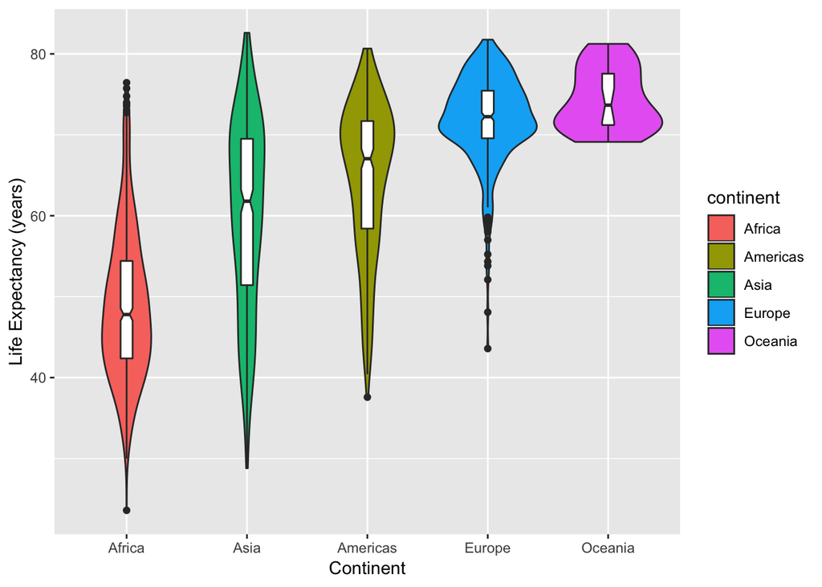

```r
# violin plot of life expectancy
  gapminder %>%
    ggplot(aes(x = reorder(continent, lifeExp, FUN = median),
               y = lifeExp,
               fill = continent)) +
    geom_violin() +
    geom_boxplot(width = 0.1, notch = T, fill = "white") +
    xlab("Continent") +
    ylab("Life Expectancy (years)")
```

Here are some other ways to create a violin plot using the `vioplot` package.

```r
# other violplot options
  # vioplot(gapminder$lifeExp)
  # vioplot(gapminder$lifeExp ~ gapminder$continent)
```

You can also make a violin plot using the `psych` package.

```r
# violin plot from psych package
  # violinBy(gapminder$lifeExp)
```

# Correlations & such

What if we want to look at how two variables interact?

Options for plotting with base R:

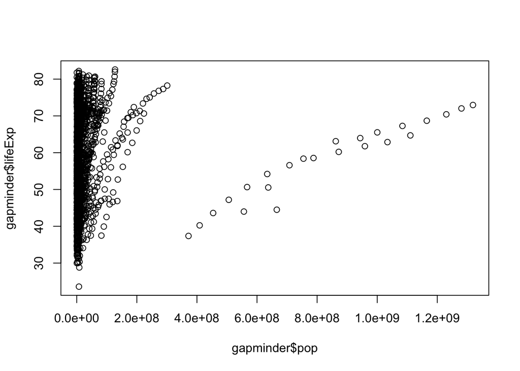

```r
# using base R
  plot(gapminder$pop, gapminder$lifeExp)
```

## Using `psych`

Using ‘psych’ we can plot histograms on scatterplots.

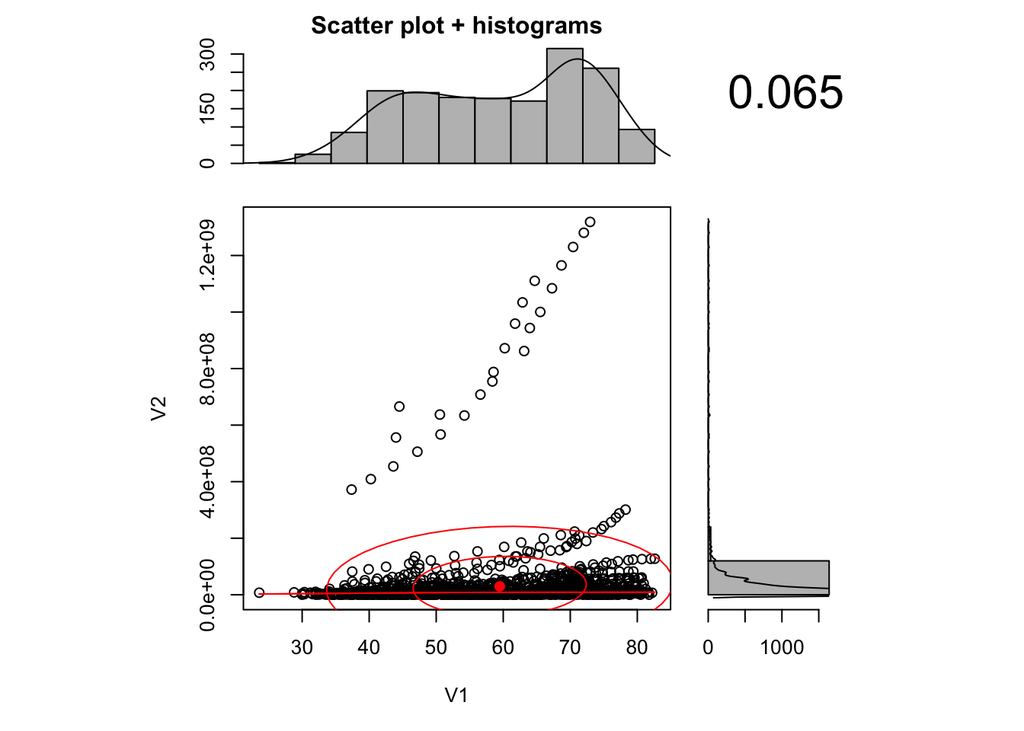

```r
# histograms on scatterplots
  scatter.hist(gapminder$lifeExp, gapminder$pop)
```

Note the order of variable changes to get the same plot.

We can look at all intearctions at once.

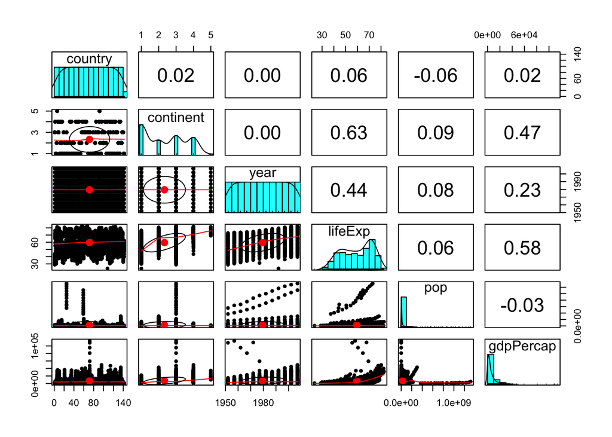

```r
# scatterplot of matrices
  pairs.panels(gapminder)
```

## Using `GGally`

This is similar to the previous function, but it takes into account the nature of the variable: numerical vs categorical.

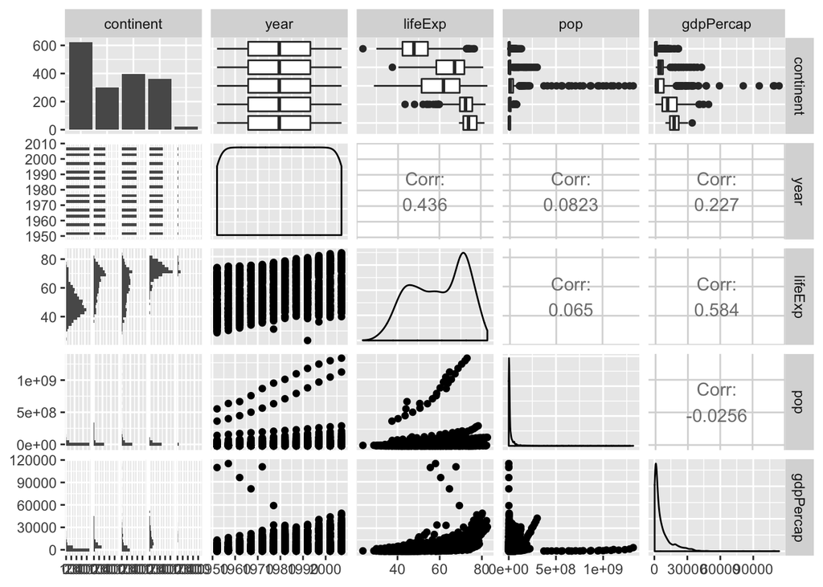

```r
# you may have to install GGally separately and then reload the library
  #install.packages("GGally")
  library(GGally)
# use ggally for pairs plot
  gapminder %>%
    select(-country) %>% # Removing countries from this calculation+plotting since there are too many!
    ggpairs()
```

Some notes: - Associations that are clear: - Life expectancy vs. Continent - GDP per capita vs. Continent - Associations that are not so clear: - Life expectancy vs. Population - **this requires further exploration!**

And of course, there are plenty of ways to tailor scatterplots using ggplot2 package. Check out all the variations below in your own time!

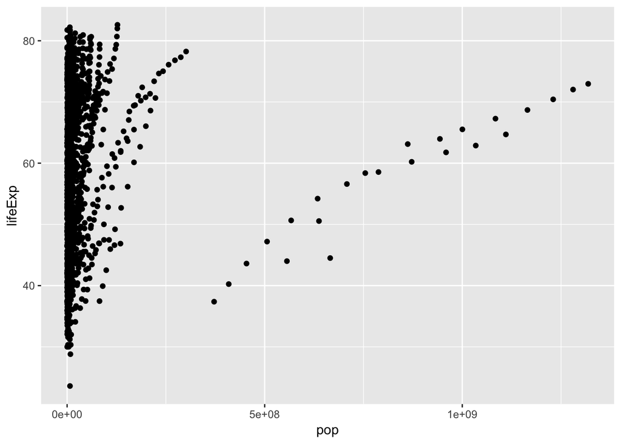

```r
# even with attach, we must still include dataset
  gapminder %>%
    ggplot(aes(x=pop, y=lifeExp)) +
    geom_point() # scatterplot
```

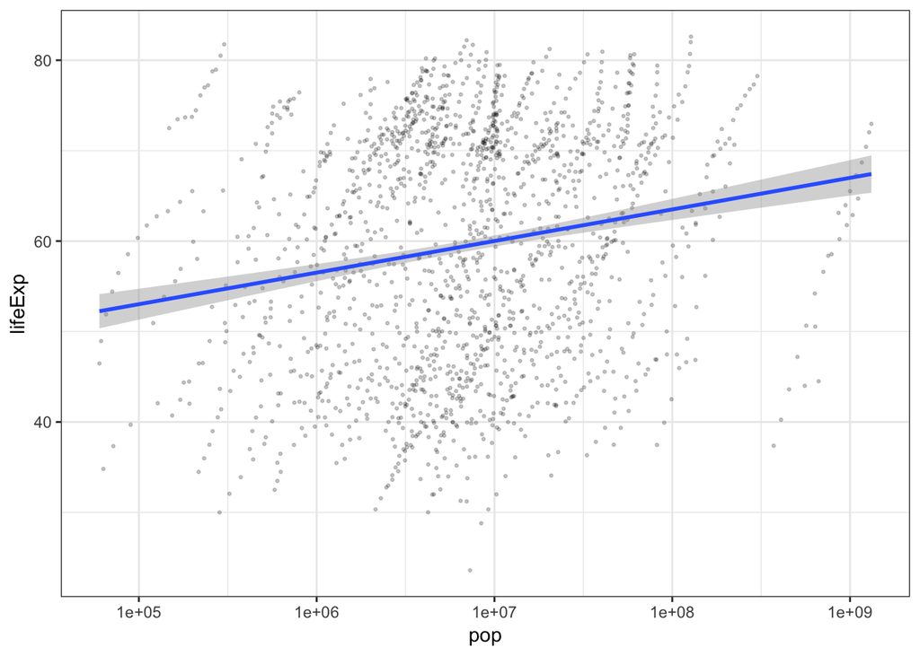

```r
# Over-plotting & data is squished along pop
  gapminder %>%
    ggplot(aes(x = pop, y = lifeExp)) +
    geom_point(size = 0.5, alpha = 0.2) + # scatterplot w/ transparency, adjusting size
    scale_x_log10() + # log x-axis
    geom_smooth(method = "lm") +
    theme_bw() # simple b/w background, not the usual grey
```

```r
# Overall correlation between population & life expectancy
  cor(gapminder$pop, gapminder$lifeExp)
```

```
## [1] 0.06495537
```

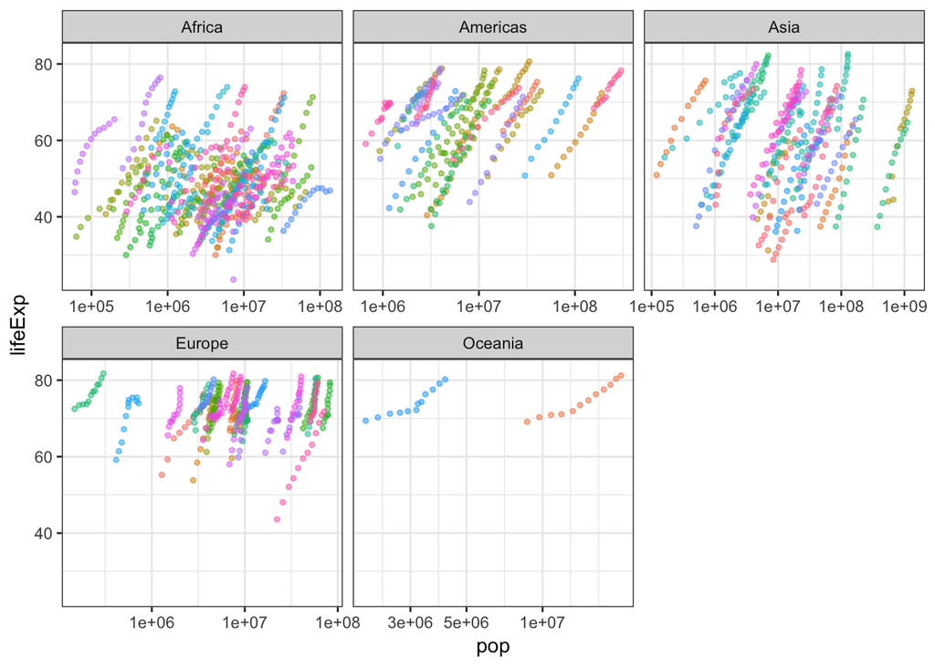

```r
# What about by country?
  gapminder %>%
    ggplot(aes(x = pop, y = lifeExp,
               color = country, fill = country)) + # coloring by countries
    facet_wrap(~continent, scales= "free_x") + # split plots by continent
    geom_point(shape = 21, size = 1, alpha = 0.5) + # scatterplot, adjusting shape of the point, size and transparency
    scale_x_log10() + # log x-axis
    theme_bw() + # simple b/w background, not the usual grey
    theme(legend.position="none") # removing legend
```

Plotting specific countries:

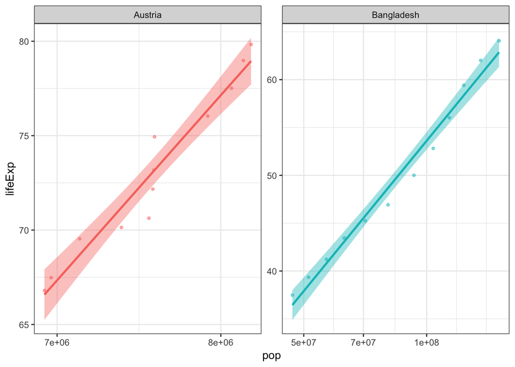

```r
# Specific countries
  gapminder %>%
    filter(country %in% c("Austria", "Bangladesh")) %>%
    ggplot(aes(x = pop, y = lifeExp,
               color = country, fill = country)) + # coloring by countries
    facet_wrap(~country, scales = "free") + # split plots by continent; independent scales
    geom_point(shape = 21, size = 1, alpha = 0.5) + # scatterplot, adjusting shape of the point, size and transparency
    scale_x_log10() + # log x-axis
    geom_smooth(method = "lm", size = 1) +
    theme_bw() + # simple b/w background, not the usual grey
    theme(legend.position="none")
```

Plotting for all countries:

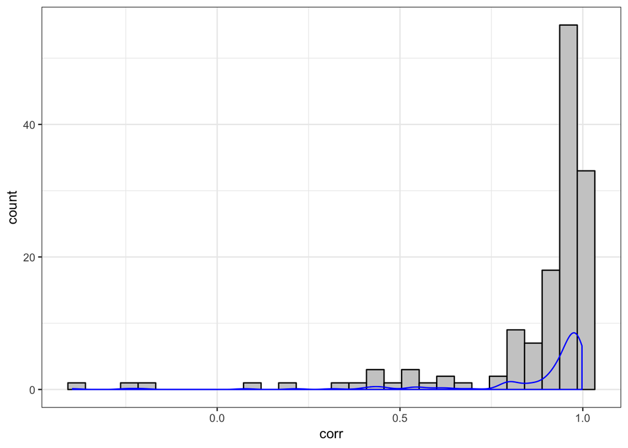

```r
gapminder %>%
  group_by(country) %>%
  summarize(corr = cor(pop, lifeExp)) %>%
  ggplot(aes(x = corr)) +
  geom_histogram(color = "black", fill = "grey80") +
  geom_density(color = "blue") +
  theme_bw()
```

# Saving plots

## Using ggsave

Google & try out later!